# Carteira de Mínima Variância usando R

José Clementino

10 novembro de 2020

# 1 Introdução

Nesse breve texto, eu[^1] introduzirei o portfólio de mínima variância: uma carteira composta por diversos ativos em que os pesos de cada um dos produtos participantes minimizam a variância total do portfólio. Essa é uma ideia bastante antiga, sendo introduzida inicialmente por MARKOWITZ (1952) e é princípio fundamental da teoria moderna de portfólios. Primeiro vamos começar com um portfólio simples que contenha apenas dois ativos e depois vamos encontrar um meio de generalizar isso para mais ativos.

# 2 A ideia

Vamos dizer que você quer montar uma carteira[^2] com dois ativos e quer que a combinação resulte na menor volatilidade possível. Como fazemos isso? Suponha dois ativos X e Y cujos retornos sejam variáveis aleatórias. O nosso objetivo é escolher um $\alpha$ que que minimize:

$$\begin{align*}
Var(\alpha X + (1-\alpha)Y)
\end{align*}$$
Lembre-se que:

$$\begin{align*}
Var(\alpha X + (1-\alpha)Y) = \alpha^2Var(X) + (1-\alpha)^2Var(Y) +2\alpha(1-\alpha)Cov(X, Y)
\end{align*}$$

Se você não estiver muito seguro(a) quanto ao seu conhecimento de cálculo I, confie em mim quando eu digo que a variância é uma função convexa. Sabendo disso, o ponto crítico da variância é um ponto de mínimo. Quando derivamos a função com relação a $\alpha$, igualamos a $0$ e fazemos algumas pequenas manipulações vamos obter:

$$\begin{align}
\frac{d(Var(\alpha X + (1-\alpha)Y)}{d\alpha} = 0 &\iff 2\alpha Var(x) - 2(1-\alpha)Var(Y) + 2(1-\alpha)Cov(X, Y)-2\alpha Cov(X, Y)=0\\
&\iff 2\alpha Var(X)-2Var(Y)+2\alpha Var(Y) + 2Cov(X, Y) - 4\alpha Cov(X, Y) = 0\\
&\iff 2\alpha Var(X) +2\alpha Var(Y) - 4\alpha Cov(X, Y) = 2Var(Y)-2Cov(X, Y) \\
&\iff 2\alpha[Var(X)+Var(Y)-2Cov(X, Y)] = 2Var(Y) - 2Cov(X, Y)\\
&\iff \alpha = \frac{Var(Y) - Cov(X, Y)}{Var(X)+Var(Y)-2Cov(X, Y)}
\end{align}$$

Pronto, encontramos o $\alpha$ que minimiza a variância de uma carteira com dois ativos. Mas e se quiséssemos generalizar isso para uma carteira de $N$ ativos? QIAN; SORENSEN; HUA (2007) tem a resposta. Denotamos $\boldsymbol{\Sigma}$ como a matriz de covariância, $\boldsymbol{i}$ é um vetor em que todos os seus elementos são o número um e $\boldsymbol{w}$ é o vetor de pesos para cada um dos ativos na carteira. Daí seremos confrontados pelo seguinte problema:

$$\begin{align*}
&min\ \ \frac{1}{2}\boldsymbol{w}\boldsymbol{\Sigma}\boldsymbol{w^T}\\
&s.a. \ \boldsymbol{w\cdot i^T }= w_1+w_2+\ldots+w_N = 1
\end{align*}$$
Transformando esse problema num lagrangiano e usando cálculo vetorial, vamos descobrir que o vetor de mínima variância será:

$$\begin{align*}
\boldsymbol{w^*} = \frac{\boldsymbol{\Sigma^{-1}i^T}}{\boldsymbol{i\Sigma^{-1}i^T}}
\end{align*}$$

Da maneira que o problema foi construído, pode haver a possibilidade de que um dos pesos $w_i$ seja negativo. A restrição não seria violada de maneira alguma, mas tal peso implicaria que o gestor do carteira deveria operar vendendo a descoberto (alugar a ação em questão e vendê-la). Para garantir que os pesos sejam positivos, uma outra restrição importante deve ser adicionada ao problema:

$$\begin{align*}
w_i\geq 0,\ i\in\{1,\dots ,N\}
\end{align*}$$
Tal restrição torna a natureza do problema mais complexa. Na verdade, o problema em questão não contém solução analítica quando as restrições são mistas QIAN; SORENSEN; HUA (2007, p. 375), isso nos leva a solucionar o problema numericamente. RUPPERT; MATTESON (2015) explicam o método que eu utilizarei para resolver o problema. Mais a frente, quando formos utilizá-lo, eu te darei uma ideia geral de como ele funciona.

# 3 Construindo carteiras

Os dados referentes aos preços diários serão retirados do Yahoo Finanças usando o pacote `quantmod`. Para transformar a estrutura dos dados de `xts` para `tibble`, vamos utilizar o pacote `broom`. Pretendemos usar outros pacotes da coleção `tidyverse` e, portanto, vamos convenientemente incluí-los nessa lista. O período de tempo que vamos usar é de 02 de fevereiro de 2020 até o final de outubro desse mesmo ano.

## 3.1 Carteira de 2 ativos

Vamos começar com o exemplo mais simples estimando um $\alpha$ que minimize uma carteira de dois ativos com base na amostra.

```r
library(quantmod)
library(tidyverse)
library(broom)


# objeto com o nome dos ativos

tickers <- c("PSSA3.SA", "ITUB3.SA")

# baixando os dados e calculando os retornos aritméticos diários

suppressWarnings(getSymbols(tickers, from = "2020-02-02", to ="2020-10-31", warnings = FALSE))
```

```
[1] "PSSA3.SA" "ITUB3.SA"
```

```r
x <- suppressWarnings(dailyReturn(get(tickers[1])))
y <- suppressWarnings(dailyReturn(get(tickers[2])))

returns <- tidy(merge(x, y)) %>%
  pivot_wider(names_from = series, values_from = value) %>%
  set_names(., nm = c("date", tickers))
returns
```

| date | PSSA3.SA | ITUB3.SA |
| --- | --- | --- |
| 2020-02-03 | -0.0080363764 | 0.0006766238 |
| 2020-02-04 | -0.0009171049 | 0.0067613590 |
| 2020-02-05 | 0.0018360159 | 0.0013431497 |
| 2020-02-06 | 0.0056505037 | -0.0043594567 |
| 2020-02-07 | 0.0098709494 | 0.0026944762 |
| 2020-02-10 | -0.0054135489 | 0.0094054081 |
| 2020-02-11 | 0.0160265802 | 0.0419301179 |
| 2020-02-12 | 0.0089286611 | 0.0051101886 |
| 2020-02-13 | -0.0210914445 | -0.0177946939 |
| 2020-02-14 | -0.0048214553 | -0.0129407959 |

[output cut: 176 more lines]

Uma breve olhada nos dados sugere que o retorno dos ativos escolhidos são correlacionados:

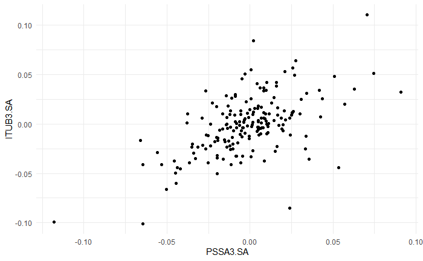

```r
theme_set(theme_minimal())


returns %>%
  ggplot(aes(x = PSSA3.SA, y = ITUB3.SA)) +
  geom_point()
```

Com os dados prontos, agora só temos que definir a função com base no nosso primeiro resultado e encontrar o peso ótimo para cada um dos ativos. A função está definida como em JAMES et al. (2017, p. 194).

```r
min_var_1 <- function(data){
  data <- data[, -1]
  x <- pull(data, 1)  #dplyr::pull extrai a coluna como vetor
  y <- pull(data, 2)

  alpha <- (var(y) - cov(x, y)) / (var(x) + var(y) - 2*cov(x, y))
  return(alpha)
}

# aplicando a função nos nossos dados

min_var_1(returns)
```

```
[1] 0.6249287
```

Numa carteira de dois ativos teríamos um $\alpha = 0,6249287$. Ou seja, para minimizar a variância da carteira, a cada um real investido, cerca de $R\$0,62$ devem ser investidos em PSSA3.